# R Notebook

## Bibliotecas

Bastante utilizada, no geral, os gráficos são mais bonitos (fica como alternativa caso sobre tempo).

Biblioteca que encontrei para realizar consultas, lembrando SQL, em dados.

Uso principal para realizar operações do tipo GROUP_BY.

```r
library(ggplot2)
library(ggplot2)
library(tidyverse)
library(ggplot2)
library(tidyverse)
library(RColorBrewer)
```

Biblioteca com diversas paletas de cores para deixar os gráficos mais bonitos.

Biblioteca para facilitar análise de correlações.

## Banco de Dados

Carregando o banco de dados.

Listando as colunas contidas no banco de dados.

```r
names(dataset)
```

```
 [1] "CO_REGIAO_RESIDENCIA"    "SG_UF_RESIDENCIA"        "NU_IDADE"                "TP_SEXO"
 [5] "TP_COR_RACA"             "TP_ST_CONCLUSAO"         "TP_ANO_CONCLUIU"         "TP_ESCOLA"
 [9] "SG_UF_ESC"               "TP_DEPENDENCIA_ADM_ESC"  "TP_LOCALIZACAO_ESC"      "IN_BAIXA_VISAO"
[13] "IN_CEGUEIRA"             "IN_SURDEZ"               "IN_DEFICIENCIA_AUDITIVA" "IN_SURDO_CEGUEIRA"
[17] "IN_DEFICIENCIA_FISICA"   "IN_DEFICIENCIA_MENTAL"   "IN_DEFICIT_ATENCAO"      "IN_DISLEXIA"
[21] "IN_DISCALCULIA"          "IN_AUTISMO"              "IN_VISAO_MONOCULAR"      "IN_OUTRA_DEF"
[25] "TP_PRESENCA_CN"          "TP_PRESENCA_CH"          "TP_PRESENCA_LC"          "TP_PRESENCA_MT"
[29] "NU_NOTA_CN"              "NU_NOTA_CH"              "NU_NOTA_LC"              "NU_NOTA_MT"
[33] "TP_LINGUA"               "TP_STATUS_REDACAO"       "NU_NOTA_REDACAO"         "Q001"
[37] "Q002"                    "Q006"                    "Q025"
```

Substituição de todos os campos em branco (NULL) por 0.

Listando as cinco primeiras linhas do banco de dados.

|  | CO_REGIAO_RESIDENCIA | SG_UF_RESIDENCIA | NU_IDADE | TP_SEXO | TP_COR_RACA | TP_ST_CONCLUSAO | TP_ANO_CONCLUIU | TP_ESCOLA | SG_UF_ESC | TP_DEPENDENCIA_ADM_ESC | TP_LOCALIZACAO_ESC | IN_BAIXA_VISAO | IN_CEGUEIRA | IN_SURDEZ | IN_DEFICIENCIA_AUDITIVA | IN_SURDO_CEGUEIRA | IN_DEFICIENCIA_FISICA | IN_DEFICIENCIA_MENTAL | IN_DEFICIT_ATENCAO | IN_DISLEXIA | IN_DISCALCULIA | IN_AUTISMO | IN_VISAO_MONOCULAR | IN_OUTRA_DEF | TP_PRESENCA_CN | TP_PRESENCA_CH | TP_PRESENCA_LC | TP_PRESENCA_MT | NU_NOTA_CN | … |
| --- | --- | --- | --- | --- | --- | --- | --- | --- | --- | --- | --- | --- | --- | --- | --- | --- | --- | --- | --- | --- | --- | --- | --- | --- | --- | --- | --- | --- | --- | --- |
| 1 | 5 | DF | 44 | M | 1 | 2 | 0 | 2 | GO | 2 | 1 | 0 | 0 | 0 | 0 | 0 | 0 | 0 | 0 | 0 | 0 | 0 | 0 | 0 | 0 | 0 | 0 | 0 | 0.0 | … |
| 2 | 2 | MA | 23 | F | 3 | 1 | 5 | 1 |  | 0 | 0 | 0 | 0 | 0 | 0 | 0 | 0 | 0 | 0 | 0 | 0 | 0 | 0 | 0 | 1 | 1 | 1 | 1 | 521.0 | … |
| 3 | 3 | SP | 23 | F | 1 | 1 | 3 | 1 |  | 0 | 0 | 0 | 0 | 0 | 0 | 0 | 0 | 0 | 0 | 0 | 0 | 0 | 0 | 0 | 0 | 0 | 0 | 0 | 0.0 | … |
| 4 | 2 | BA | 26 | F | 3 | 1 | 8 | 1 |  | 0 | 0 | 0 | 0 | 0 | 0 | 0 | 0 | 0 | 0 | 0 | 0 | 0 | 0 | 0 | 0 | 0 | 0 | 0 | 0.0 | … |
| 5 | 2 | BA | 20 | M | 0 | 2 | 0 | 2 | BA | 2 | 1 | 0 | 0 | 0 | 0 | 0 | 0 | 0 | 0 | 0 | 0 | 0 | 0 | 0 | 0 | 1 | 1 | 0 | 0.0 | … |
| 6 | 2 | PB | 23 | F | 1 | 1 | 5 | 1 |  | 0 | 0 | 0 | 0 | 0 | 0 | 0 | 0 | 0 | 0 | 0 | 0 | 0 | 0 | 0 | 1 | 1 | 1 | 1 | 461.8 | … |

## Pré-processamentos

Abaixo, geramos um subconjunto contendo apenas as entradas de alunos que realizaram todas as provas (uma filtragem).

|  | CO_REGIAO_RESIDENCIA | SG_UF_RESIDENCIA | NU_IDADE | TP_SEXO | TP_COR_RACA | TP_ST_CONCLUSAO | TP_ANO_CONCLUIU | TP_ESCOLA | SG_UF_ESC | TP_DEPENDENCIA_ADM_ESC | TP_LOCALIZACAO_ESC | IN_BAIXA_VISAO | IN_CEGUEIRA | IN_SURDEZ | IN_DEFICIENCIA_AUDITIVA | IN_SURDO_CEGUEIRA | IN_DEFICIENCIA_FISICA | IN_DEFICIENCIA_MENTAL | IN_DEFICIT_ATENCAO | IN_DISLEXIA | IN_DISCALCULIA | IN_AUTISMO | IN_VISAO_MONOCULAR | IN_OUTRA_DEF | TP_PRESENCA_CN | TP_PRESENCA_CH | TP_PRESENCA_LC | TP_PRESENCA_MT | NU_NOTA_CN | … |
| --- | --- | --- | --- | --- | --- | --- | --- | --- | --- | --- | --- | --- | --- | --- | --- | --- | --- | --- | --- | --- | --- | --- | --- | --- | --- | --- | --- | --- | --- | --- |
| 2 | 2 | MA | 23 | F | 3 | 1 | 5 | 1 |  | 0 | 0 | 0 | 0 | 0 | 0 | 0 | 0 | 0 | 0 | 0 | 0 | 0 | 0 | 0 | 1 | 1 | 1 | 1 | 521.0 | … |
| 6 | 2 | PB | 23 | F | 1 | 1 | 5 | 1 |  | 0 | 0 | 0 | 0 | 0 | 0 | 0 | 0 | 0 | 0 | 0 | 0 | 0 | 0 | 0 | 1 | 1 | 1 | 1 | 461.8 | … |
| 8 | 2 | PI | 39 | M | 3 | 1 | 12 | 1 |  | 0 | 0 | 0 | 0 | 0 | 0 | 0 | 0 | 0 | 0 | 0 | 0 | 0 | 0 | 0 | 1 | 1 | 1 | 1 | 499.3 | … |
| 9 | 2 | CE | 19 | M | 3 | 2 | 0 | 2 | CE | 2 | 1 | 0 | 0 | 0 | 0 | 0 | 0 | 0 | 0 | 0 | 0 | 0 | 0 | 0 | 1 | 1 | 1 | 1 | 411.8 | … |
| 10 | 5 | MT | 25 | F | 3 | 1 | 9 | 1 |  | 0 | 0 | 0 | 0 | 0 | 0 | 0 | 0 | 0 | 0 | 0 | 0 | 0 | 0 | 0 | 1 | 1 | 1 | 1 | 469.4 | … |
| 13 | 1 | TO | 18 | F | 2 | 1 | 1 | 1 |  | 0 | 0 | 0 | 0 | 0 | 0 | 0 | 0 | 0 | 0 | 0 | 0 | 0 | 0 | 0 | 1 | 1 | 1 | 1 | 467.4 | … |

## Boxplot das Notas (visualizar média, mediana, quartis).

### Preparando os Dados

Geramos um novo data frame contendo as colunas de notas.

[figure not shown]

### Gerando o Gráfico

Código para gerar o gráfico (o bloco abaixo precisa ser executado de uma vez, por completo).

```r
boxplot(
  grades,
  names = c("", "", "", "", ""),
  par(mar = c(7, 4, 2, 2) + 0.1),
  ylab = "Notas",
  main = "Notas por Área do Conhecimento"
  )

title(xlab="Áreas do Conhecimento", line=6)
```

[figure not shown]

```r
text(
  seq(1.2, 6, by=1),
  par("usr")[3],
  srt = 45,
  adj= 1.3,
  xpd = TRUE,
  labels = areas_names,
  )
```

## Análise das Notas por Sexo

### Preparando os Dados

Agrupamos os dados pelo gênero (M e F) e depois calculamos as médias das notas para cada área do conhecimento.

| TP_SEXO | NOTA_CN_MEAN | NOTA_CH_MEAN | NOTA_LC_MEAN | NOTA_MT_MEAN | NOTA_RD_MEAN |
| --- | --- | --- | --- | --- | --- |
| F | 488.9929 | 566.4753 | 525.7392 | 518.3447 | 519.6946 |
| M | 500.6476 | 577.0799 | 532.5310 | 560.2741 | 510.8027 |

### Gerando o Gráfico

Agora, que já temos os dados necessários, precisamos formatar eles para facilitar o uso com a função que gerará o gráfico.

O ideal seria utilizar alguma função para realizar a formatação mas, para agilizar e evitar estresse, iremos fazer manualmente.

```r
sex_gb_data_fmt
```

```
         M        F
0 500.6476 488.9929
1 510.8027 519.6946
2 532.5310 525.7392
3 560.2741 518.3447
4 577.0799 566.4753
```

Código para gerar o gráfico (o bloco abaixo precisa ser executado de uma vez, por completo).

```r
# Ajusta as dimensões do retângulo sobre o qual o gráfico é desenhado.
# Isto é necessário para que os títulos dispostos ao longo do eixo Y fiquem visíveis.

par(mar = c(4, 8, 4, 3))

# Criamos dois vetores, um com as médias dos homens e outro com as médias das mulheres.
# Apenas para facilitar passar os dados para a função que desenha o gráfico

m_data = sex_gb_data_fmt[,"M"]
f_data = sex_gb_data_fmt[,"F"]

# Intervalo com a menor e maior média.

grades_range = range(c(m_data, f_data))

# Gera o gráfico sem as linhas, legendas e o grid.

plot(
  grades_range,
  c(1, 5),
  type = "n",
  xaxs = "i",
  yaxt = "n",
  main = "Desempenho das Disciplinas por Área e Sexo",
  xlab = "Média das Notas",
  ylab = "",
  xlim = c(400, 700),
  panel.first = c(
      abline(h=1, col=alpha("gray", 0.2), lwd=8),
      abline(h=2, col=alpha("gray", 0.2), lwd=8),
      abline(h=3, col=alpha("gray", 0.2), lwd=8),
      abline(h=4, col=alpha("gray", 0.2), lwd=8),
      abline(h=5, col=alpha("gray", 0.2), lwd=8)
    )
  )

# Adiciona o grid e dispõe o texto ao longo do eixo Y.

grid (NULL, NULL, lty = 6, col = "cornsilk2")
```

```r
axis(2, at = c(1:5), labels = FALSE)
text(y = c(1:5), par("usr")[1], labels = areas_names, srt = 0, pos = 2, xpd = TRUE)
```

```r
# Desenha as duas linhas (homes e mulheres).

lines(m_data, c(1:5), type = "o", lwd = 2, lty="dotted", col = "blue")
lines(f_data, c(1:5), type = "o", lwd = 2, lty="dotted", col = "red")
```

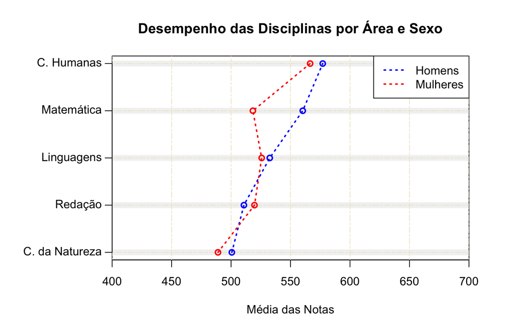

```r
# Adiciona a legenda das linhas.

legend("topright", lty = "dotted", lwd = 2, col=c("blue", "red"), legend = c("Homens", "Mulheres"))
```

## Análise das Notas por Região

### Preparando os Dados

Agrupamos os dados por região (N, NE, SE, S e MW) e depois calculamos as médias das notas para cada área do conhecimento.

| CO_REGIAO_RESIDENCIA | NOTA_CN_MEAN | NOTA_CH_MEAN | NOTA_LC_MEAN | NOTA_MT_MEAN | NOTA_RD_MEAN |
| --- | --- | --- | --- | --- | --- |
| NORTE | 473.8624 | 548.3448 | 505.6513 | 505.2629 | 480.2929 |
| NORDESTE | 480.9937 | 556.4959 | 513.9111 | 520.2293 | 500.9236 |
| SUDESTE | 508.3383 | 586.6912 | 544.9365 | 556.2115 | 540.1123 |
| SUL | 504.4326 | 586.9306 | 542.8668 | 547.8609 | 523.2844 |
| CENTRO-OESTE | 494.8638 | 568.8757 | 528.2555 | 531.4668 | 511.0313 |

### Gerando o Gráfico

Agora, que já temos os dados necessários, precisamos formatar eles para facilitar o uso com a função que gerará o gráfico.

O ideal seria utilizar alguma função para realizar a formatação mas, para agilizar e evitar estresse, iremos fazer manualmente.

```r
region_gb_data_fmt
```

```
                   CN       CH       LC       MT       RD
NORTE        473.8624 548.3448 505.6513 505.2629 480.2929
NORDESTE     480.9937 556.4959 513.9111 520.2293 500.9236
SUDESTE      508.3383 586.6912 544.9365 556.2115 540.1123
SUL          504.4326 586.9306 542.8668 547.8609 523.2844
CENTRO-OESTE 494.8638 568.8757 528.2555 531.4668 511.0313
```

Código para gerar o gráfico (o bloco abaixo precisa ser executado de uma vez, por completo).

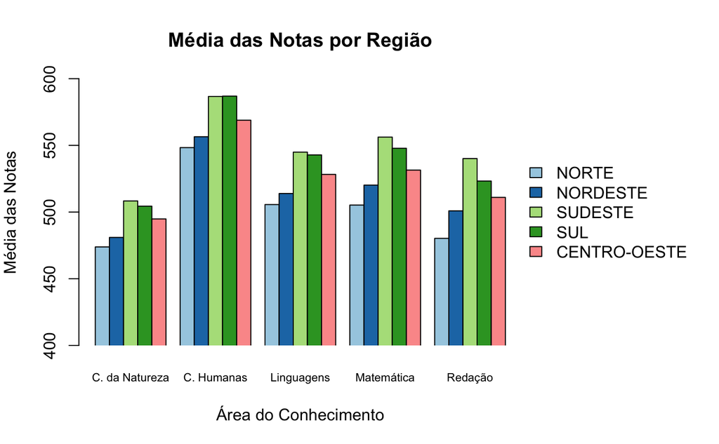

```r
par(mar = c(5,4,4,10))

barplot(
  region_gb_data_fmt,
  main = "Média das Notas por Região",
  xlab = "Área do Conhecimento",
  ylab = "Média das Notas",
  col=brewer.pal(nrow(region_gb_data_fmt), "Paired"),
  names.arg = c("C. da Natureza", "C. Humanas", "Linguagens", "Matemática", "Redação"),
  cex.names = 0.70,
  ylim = c(400, 600),
  beside = TRUE,
  legend = rownames(region_gb_data_fmt),
  args.legend = list(x ='right', bty='n', inset=c(-0.39,0), xpd = TRUE),
  xpd = FALSE
  )
```

## Análise das Notas por Anos pós Formatura no Ensino Médio

### Preparando os Dados

Abaixo, geramos um subconjunto contendo apenas as entradas de alunos que realizaram todas as provas e informaram o ano de conclusão do ensino médio (uma filtragem).

Agrupamos os dados pelo número de anos desde a conclusão do ensino médio e depois calculamos as médias das notas para cada área do conhecimento.

| TP_ANO_CONCLUIU | NOTA_CN_MEAN | NOTA_CH_MEAN | NOTA_LC_MEAN | NOTA_MT_MEAN | NOTA_RD_MEAN |
| --- | --- | --- | --- | --- | --- |
| 1 | 498.4525 | 573.7264 | 532.8030 | 541.5357 | 544.5676 |
| 2 | 498.4684 | 574.1270 | 533.5877 | 541.5881 | 539.9269 |
| 3 | 496.2037 | 572.7351 | 531.7910 | 538.6611 | 529.9921 |
| 4 | 495.3493 | 573.8095 | 532.5863 | 537.2496 | 521.5879 |
| 5 | 494.1237 | 574.3243 | 532.1315 | 534.6175 | 511.9225 |
| 6 | 492.4198 | 574.8060 | 531.4086 | 532.2354 | 503.4143 |
| 7 | 493.0256 | 576.9054 | 532.5693 | 532.4638 | 500.5351 |
| 8 | 491.1260 | 574.6819 | 528.6013 | 526.9232 | 488.7527 |
| 9 | 491.9990 | 576.4254 | 529.2636 | 525.4294 | 487.9442 |
| 10 | 493.8888 | 578.0239 | 529.0768 | 525.1752 | 486.4491 |

[output cut: 2 more lines]

### Gerando o Gráfico

Agora, que já temos os dados necessários, precisamos formatar eles para facilitar o uso com a função que gerará o gráfico.

O ideal seria utilizar alguma função para realizar a formatação mas, para agilizar e evitar estresse, iremos fazer manualmente.

```r
em_gp_data_fmt
```

[output not shown]

Código para gerar o gráfico (o bloco abaixo precisa ser executado de uma vez, por completo).

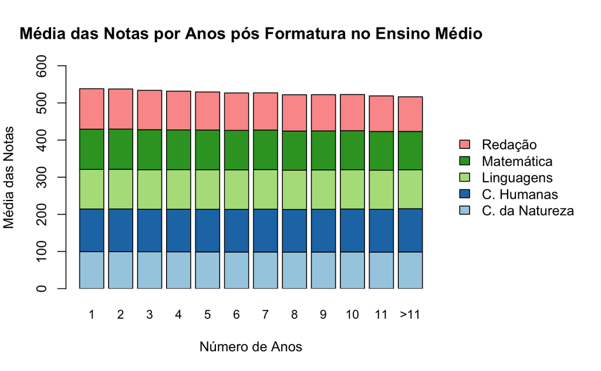

```r
par(mar = c(5, 4 , 4, 10))

barplot(
  em_gp_data_fmt,
  main="Média das Notas por Anos pós Formatura no Ensino Médio",
  xlab="Número de Anos",
  ylab = "Média das Notas",
  col=brewer.pal(nrow(em_gp_data_fmt), "Paired"),
  names.arg = c("1", "2", "3", "4", "5", "6", "7", "8", "9", "10", "11", ">11"),
  legend = c("C. da Natureza", "C. Humanas", "Linguagens", "Matemática", "Redação"),
  cex.names = 0.9,
  ylim = c(0, 600),
  args.legend = list(x ='right', bty='n', inset=c(-0.39,0), xpd = TRUE),
  xpd = FALSE
  )
```

### Preparando os Dados

| Q001 | NOTA_MEAN |
| --- | --- |
| A | 479.4759 |
| B | 499.0910 |
| C | 514.5845 |
| D | 524.8589 |
| E | 544.3216 |
| F | 592.5938 |
| G | 610.2344 |

```r
father_gb_data

mother_gb_data
```

| Q002 | NOTA_MEAN |
| --- | --- |
| A | 474.9720 |
| B | 494.4802 |
| C | 507.8539 |
| D | 516.2735 |
| E | 535.8166 |
| F | 578.8811 |
| G | 590.4543 |

```r
NA
```

### Gerando o Gráfico

Agora, que já temos os dados necessários, precisamos formatar eles para facilitar o uso com a função que gerará o gráfico.

O ideal seria utilizar alguma função para realizar a formatação mas, para agilizar e evitar estresse, iremos fazer manualmente.

```r
parents_gb_data_fmt
```

```
         F        M
0 479.4759 474.9720
1 499.0910 494.4802
2 514.5845 507.8539
3 524.8589 516.2735
4 544.3216 535.8166
5 592.5938 578.8811
6 610.2344 590.4543
```

Código para gerar o gráfico (o bloco abaixo precisa ser executado de uma vez, por completo).

```r
# Ajusta as dimensões do retângulo sobre o qual o gráfico é desenhado.
# Isto é necessário para que os títulos dispostos ao longo do eixo Y fiquem visíveis.

par(mar = c(4, 10, 4, 3))

# Criamos dois vetores, um com as médias dos pais e outro com as médias das mães.
# Apenas para facilitar passar os dados para a função que desenha o gráfico

f_data = parents_gb_data_fmt[,"F"]
m_data = parents_gb_data_fmt[,"M"]

# Intervalo com a menor e maior média.

grades_range = range(c(f_data, m_data))

# Gera o gráfico sem as linhas, legendas e o grid.

plot(
  grades_range,
  c(1, 7),
  type = "n",
  xaxs = "i",
  yaxt = "n",
  main = "Desempenho nas Disciplinas por Escolaridade dos Pais",
  xlab = "Média das Notas",
  ylab = "",
  xlim = c(400, 700),
  panel.first = c(
      abline(h=1, col=alpha("gray", 0.2), lwd=8),
      abline(h=2, col=alpha("gray", 0.2), lwd=8),
      abline(h=3, col=alpha("gray", 0.2), lwd=8),
      abline(h=4, col=alpha("gray", 0.2), lwd=8),
      abline(h=5, col=alpha("gray", 0.2), lwd=8),
      abline(h=6, col=alpha("gray", 0.2), lwd=8),
      abline(h=7, col=alpha("gray", 0.2), lwd=8)
    )
  )

# Adiciona o grid e dispõe o texto ao longo do eixo Y.

grid (NULL, NULL, lty = 6, col = "cornsilk2")
```

```r
axis(2, at = c(1:7), labels = FALSE)
text(y = c(1:7), par("usr")[1], labels = education_names, srt = 0, pos = 2, xpd = TRUE)
```

```r
# Desenha as duas linhas (pais e mães).

lines(f_data, c(1:7), type = "o", lty="dotted", lwd = 2, col = "blue")
lines(m_data, c(1:7), type = "o", lty="dotted", lwd = 2, col = "red")
```

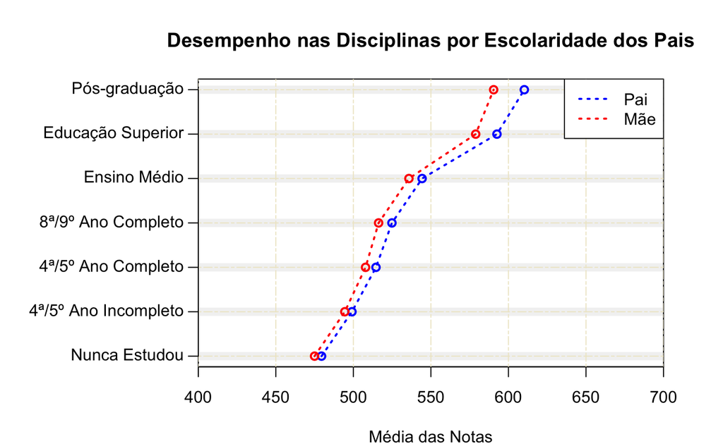

```r
# Adiciona a legenda das linhas.

legend("topright", lty = "dotted", lwd = 2, col=c("blue", "red"), legend = c("Pai", "Mãe"))
```

### Aplicando o Teste T-student

```r
t.test(sample(father_a, 10000), sample(mother_a, 10000), alternative = "two.sided", var.equal = FALSE)
```

```
    Welch Two Sample t-test

data:  sample(father_a, 10000) and sample(mother_a, 10000)
t = 5.3985, df = 19998, p-value = 6.795e-08
alternative hypothesis: true difference in means is not equal to 0
95 percent confidence interval:
 3.070058 6.570214
sample estimates:
mean of x mean of y
 479.9297  475.1096
```

## Média das Notas por Faixa de Renda

### Preparando os Dados

Agrupamos os dados pela renda familiar (A..Q) e depois calculamos as médias das notas para cada área do conhecimento.

| Q006 | NOTA_CN_MEAN | NOTA_CH_MEAN | NOTA_LC_MEAN | NOTA_MT_MEAN | NOTA_RD_MEAN |
| --- | --- | --- | --- | --- | --- |
| A | 461.3834 | 534.4840 | 489.0129 | 488.1951 | 439.8823 |
| B | 464.2876 | 538.7842 | 495.5834 | 493.4488 | 453.7553 |
| C | 477.9436 | 557.3450 | 515.1368 | 511.3698 | 483.8833 |
| D | 490.9509 | 571.6759 | 529.7742 | 532.4097 | 508.1082 |
| E | 495.8044 | 577.0594 | 535.6683 | 537.7704 | 522.6276 |
| F | 507.9744 | 588.2437 | 546.8257 | 557.9506 | 546.4558 |
| G | 513.7103 | 593.7454 | 552.7406 | 565.2385 | 561.3130 |
| H | 527.5482 | 604.4753 | 563.2233 | 584.2216 | 588.6178 |
| I | 536.3463 | 611.5585 | 569.9358 | 596.7370 | 608.2605 |
| J | 546.2806 | 618.9006 | 577.4429 | 609.8811 | 628.3137 |

[output cut: 7 more lines]

### Gerando o Gráfico

Agora, que já temos os dados necessários, precisamos formatar eles para facilitar o uso com a função que gerará o gráfico.

O ideal seria utilizar alguma função para realizar a formatação mas, para agilizar e evitar estresse, iremos fazer manualmente.

```r
income_gp_data_fmt
```

```
          [,1]      [,2]      [,3]      [,4]      [,5]     [,6]     [,7]     [,8]     [,9]    [,10]    [,11]    [,12]    [,13]    [,14]    [,15]    [,16]    [,17]
[1,]  92.27667  92.85752  95.58873  98.19017  99.16088 101.5949 102.7421 105.5096 107.2693 109.2561 110.4267 111.8982 112.5343 113.8975 115.2362 116.4753 117.8268
[2,] 106.89679 107.75685 111.46900 114.33518 115.41189 117.6487 118.7491 120.8951 122.3117 123.7801 124.6475 125.8031 126.2104 127.2962 128.3829 129.2657 130.5042
[3,]  97.80258  99.11669 103.02737 105.95485 107.13366 109.3651 110.5481 112.6447 113.9872 115.4886 116.2460 117.2808 117.7251 118.7477 119.8285 120.7188 121.8396
[4,]  97.63903  98.68977 102.27397 106.48195 107.55409 111.5901 113.0477 116.8443 119.3474 121.9762 123.6138 125.8692 126.6925 128.9243 130.9987 133.2408 136.5284
[5,]  87.97646  90.75105  96.77666 101.62164 104.52552 109.2912 112.2626 117.7236 121.6521 125.6627 127.7386 130.7111 131.7581 133.9511 136.7290 138.6562 141.5493
```

Código para gerar o gráfico (o bloco abaixo precisa ser executado de uma vez, por completo).

```r
par(mar = c(5, 4 , 4, 10))

barplot(
  income_gp_data_fmt,
  main="Média das Notas por Renda Familiar",
  ylab = "Média das Notas",
  col=brewer.pal(nrow(income_gp_data_fmt), "Paired"),
  legend = c("C. da Natureza", "C. Humanas", "Linguagens", "Matemática", "Redação"),
  ylim = c(0, 700),
  args.legend = list(x ='right', bty='n', inset=c(-0.39,0), xpd = TRUE),
  xpd = FALSE
  )

title(xlab="Renda Familiar", line=4)
```

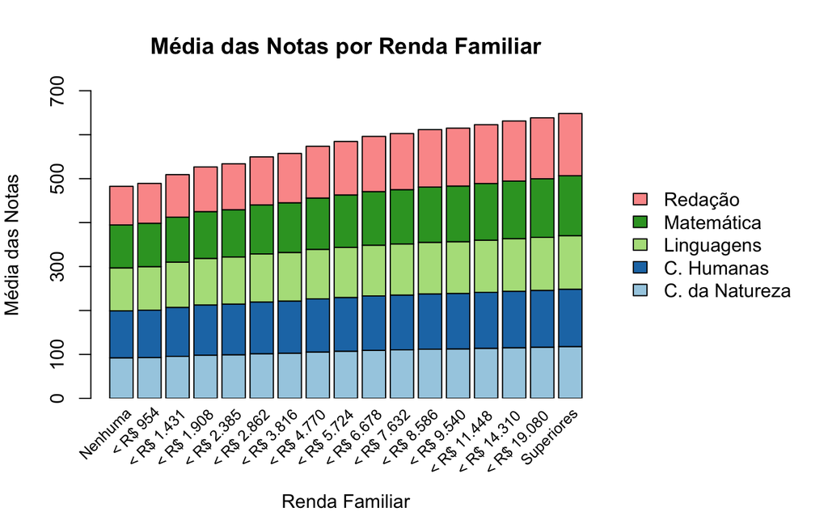

```r
names = c(
  "Nenhuma",
  "< R$ 954",
  "< R$ 1.431",
  "< R$ 1.908",
  "< R$ 2.385",
  "< R$ 2.862",
  "< R$ 3.816",
  "< R$ 4.770",
  "< R$ 5.724",
  "< R$ 6.678",
  "< R$ 7.632",
  "< R$ 8.586",
  "< R$ 9.540",
  "< R$ 11.448",
  "< R$ 14.310",
  "< R$ 19.080",
  "Superiores"
  )

text(
  seq(1.5, 21, by=1.2),
  par("usr")[3],
  srt = 45,
  adj= 1.25,
  xpd = TRUE,
  labels = names,
  cex=0.8
  )
```

## Ocorrências de Falha na Redação

### Preparando os Dados

```r
# Agrupa os dados.

reason_gb_data = fdata %>% group_by(TP_STATUS_REDACAO) %>% summarise(COUNT = n())

# Removemos as entradas para as quais a redação foi considerada válida.

reason_gb_data = reason_gb_data[-c(1),]

# Apresentando contagens.

reason_gb_data
```

[output not shown]

### Gerando o Gráfico

Agora, que já temos os dados necessários, precisamos formatar eles para facilitar o uso com a função que gerará o gráfico.

```r
counts = as.vector(unlist(reason_gb_data[,"COUNT"]))
percentages = round(100*counts/sum(counts), 1)
percentages = paste(percentages, "%", sep="")

labels = c(
  "Anulada",
  "Cópia do Texto Motivador",
  "Em Branco",
  "Fuga do Tema",
  "Tipo Textual Incorreto",
  "Texto Insuficiente",
  "Parte Desconectada"
  )

counts
percentages
```

[output not shown]

Código para gerar o gráfico (o bloco abaixo precisa ser executado de uma vez, por completo).

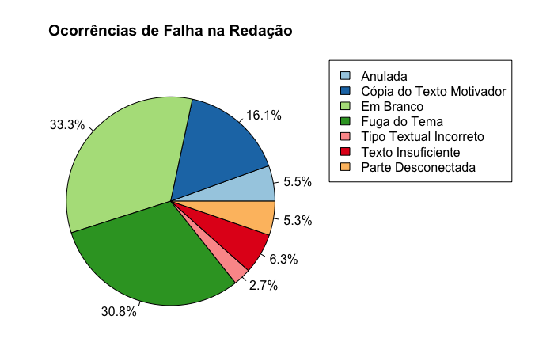

```r
#par(mfrow=c(1, 2), mai = c(1, 0, 1, 0))

par(mar = c(0, 0, 4, 14))

pie(
  counts,
  labels = percentages,
  main = "Ocorrências de Falha na Redação",
  col = brewer.pal(length(counts), "Paired")
  )

legend(
  "topright",
  labels,
  fill = brewer.pal(length(counts), "Paired"),
  inset=c(-0.5, 0),
  xpd = TRUE
  )
```

### Gerando o Gráfico

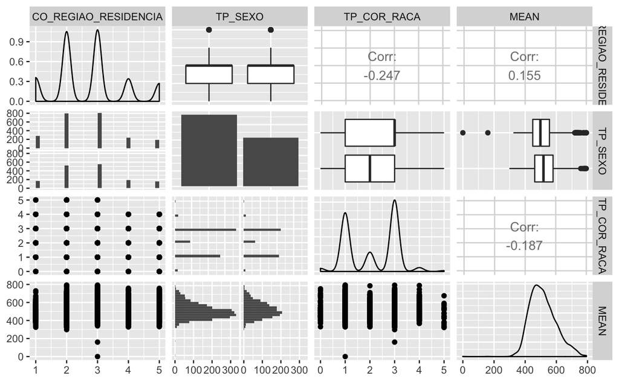

[figure not shown]